# **Statistics Project for Data Science**

### Import the libraries needed for the project

```python
## Import the libraries needed

import pandas as pd
import seaborn as sns
import matplotlib.pyplot as plt
import matplotlib.ticker as ticker
import numpy as np; np.random.seed(1)
```

### Accessing the dataframe's URL and reading in the CSV file from the URL using the request library

```python
## Access the Boston Dataframe URL
## Read in the csv file from the url using the request library

boston_url = 'https://cf-courses-data.s3.us.cloud-object-storage.appdomain.cloud/IBMDeveloperSkillsNetwork-ST0151EN-SkillsNetwork/labs/boston_housing.csv'
boston_df=pd.read_csv(boston_url)
```

### Previewing the first ten rows of the dataframe

```python
## Preview the Boston Dataframe

boston_df.head(10)
```

|  | Unnamed: 0 | CRIM | ZN | INDUS | CHAS | NOX | RM | AGE | DIS | RAD | TAX | PTRATIO | LSTAT | MEDV |
| --- | --- | --- | --- | --- | --- | --- | --- | --- | --- | --- | --- | --- | --- | --- |
| 0 | 0 | 0.00632 | 18.0 | 2.31 | 0.0 | 0.538 | 6.575 | 65.2 | 4.0900 | 1.0 | 296.0 | 15.3 | 4.98 | 24.0 |
| 1 | 1 | 0.02731 | 0.0 | 7.07 | 0.0 | 0.469 | 6.421 | 78.9 | 4.9671 | 2.0 | 242.0 | 17.8 | 9.14 | 21.6 |
| 2 | 2 | 0.02729 | 0.0 | 7.07 | 0.0 | 0.469 | 7.185 | 61.1 | 4.9671 | 2.0 | 242.0 | 17.8 | 4.03 | 34.7 |
| 3 | 3 | 0.03237 | 0.0 | 2.18 | 0.0 | 0.458 | 6.998 | 45.8 | 6.0622 | 3.0 | 222.0 | 18.7 | 2.94 | 33.4 |
| 4 | 4 | 0.06905 | 0.0 | 2.18 | 0.0 | 0.458 | 7.147 | 54.2 | 6.0622 | 3.0 | 222.0 | 18.7 | 5.33 | 36.2 |
| 5 | 5 | 0.02985 | 0.0 | 2.18 | 0.0 | 0.458 | 6.430 | 58.7 | 6.0622 | 3.0 | 222.0 | 18.7 | 5.21 | 28.7 |
| 6 | 6 | 0.08829 | 12.5 | 7.87 | 0.0 | 0.524 | 6.012 | 66.6 | 5.5605 | 5.0 | 311.0 | 15.2 | 12.43 | 22.9 |
| 7 | 7 | 0.14455 | 12.5 | 7.87 | 0.0 | 0.524 | 6.172 | 96.1 | 5.9505 | 5.0 | 311.0 | 15.2 | 19.15 | 27.1 |
| 8 | 8 | 0.21124 | 12.5 | 7.87 | 0.0 | 0.524 | 5.631 | 100.0 | 6.0821 | 5.0 | 311.0 | 15.2 | 29.93 | 16.5 |
| 9 | 9 | 0.17004 | 12.5 | 7.87 | 0.0 | 0.524 | 6.004 | 85.9 | 6.5921 | 5.0 | 311.0 | 15.2 | 17.10 | 18.9 |

### Finding out the data type of each variable in the table

```python
## Get information about each variable

boston_df.info()
```

```
<class 'pandas.core.frame.DataFrame'>
RangeIndex: 506 entries, 0 to 505
Data columns (total 14 columns):
 #   Column      Non-Null Count  Dtype
---  ------      --------------  -----
 0   Unnamed: 0  506 non-null    int64
 1   CRIM        506 non-null    float64
 2   ZN          506 non-null    float64
 3   INDUS       506 non-null    float64
 4   CHAS        506 non-null    float64
 5   NOX         506 non-null    float64
 6   RM          506 non-null    float64
 7   AGE         506 non-null    float64
 8   DIS         506 non-null    float64
 9   RAD         506 non-null    float64
 10  TAX         506 non-null    float64
 11  PTRATIO     506 non-null    float64
 12  LSTAT       506 non-null    float64
 13  MEDV        506 non-null    float64
dtypes: float64(13), int64(1)
memory usage: 55.5 KB
```

### Getting the number of rows and columns

```python
## Get the number of rows and columns - prints as (number of rows, number of columns)

boston_df.shape
```

```
(506, 14)
```

##### We can see that the dataset has 506 rows and 14 columns.

### Creating a box plot for the Median Value of Owner-Occupied Homes

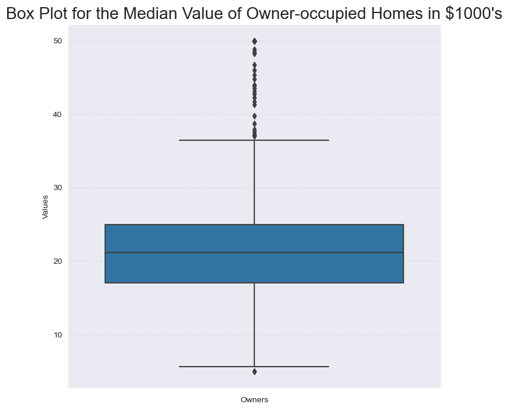

```python
## Create a box plot for the Median value of owner-occupied homes

## Set the grid layout and create the boxplot
sns.set_style("darkgrid", {"grid.color": ".8", "grid.linestyle": ":"})
plt.rcParams["figure.figsize"] = [7, 7]
plt.rcParams["figure.autolayout"] = True
ax = sns.boxplot(y="MEDV", data=boston_df)

## Create the Graph's Title and Axis labels
plt.xlabel("Owners")
plt.ylabel("Values")
plt.title("Box Plot for the Median Value of Owner-occupied Homes in $1000's", fontsize=20)

## Display the Figure
plt.show()
```

### Plotting a Bar Plot for the Charles River variable

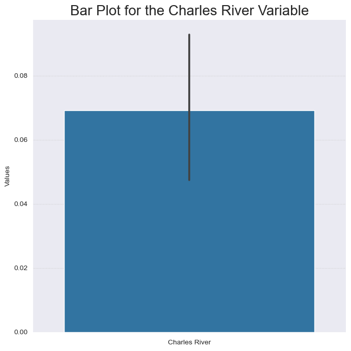

```python
## Plot the barplot for the Charles river variable

## Set the grid layout and create the barplot
sns.set_style("darkgrid", {"grid.color": ".8", "grid.linestyle": ":"})
plt.rcParams["figure.figsize"] = [7, 7]
plt.rcParams["figure.autolayout"] = True
ax = sns.barplot(y="CHAS", data=boston_df)

## Create the Graph's Title and Axis labels
plt.xlabel("Charles River")
plt.ylabel("Values")
plt.title("Bar Plot for the Charles River Variable", fontsize=20)

## Display the figure
plt.show()
```

##### According to the Bar Plot, the Charles River average value is about 0.07.

### Creating boxplot for the MEDV variable vs the AGE variable for owners who are 35 and younger

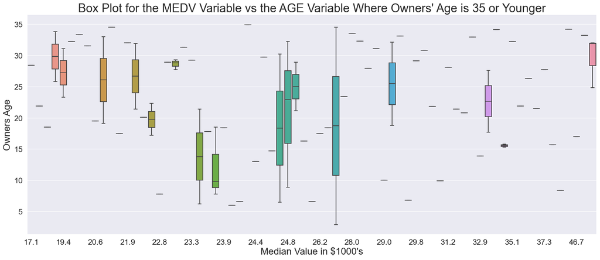

```python
## Create a box plot for the MEDV variable vs the AGE variable where the age variable is 35 years and younger

## Query the dataframe's age range for 35 or younger
young_df=boston_df.query('AGE <= 35')

## Set the grid layout, grid size, color, and axis font size
sns.set_style("darkgrid", {"grid.color": ".8", "grid.linestyle": ":"})
sns.set(font_scale = 1.5)
plt.rcParams["figure.figsize"] = [18, 8]
plt.rcParams["figure.autolayout"] = True

## Create the boxplot
ax = sns.boxplot(x="MEDV", y="AGE", data=young_df)

## Iterate ax.get_xticklabels() method. If index is even at intervals of four, then make them visible; else, don't.
for index, label in enumerate(ax.get_xticklabels()):
   if index % 4 == 0:
      label.set_visible(True)
   else:
      label.set_visible(False)

## Create the Graph's Title and Axis labels and set the font sizes
plt.xlabel("Median Value in $1000's", fontsize=20)
plt.ylabel("Owners Age", fontsize=20)
plt.title("Box Plot for the MEDV Variable vs the AGE Variable Where Owners' Age is 35 or Younger", fontsize=25)

## Display the figure
plt.show()
```

##### According to the graph, there are very few owners ages 35 or younger who own properties with the Median Value in $1000's.

### Creating boxplot for the MEDV variable vs the AGE variable for owners who are between 35 and 70 years old

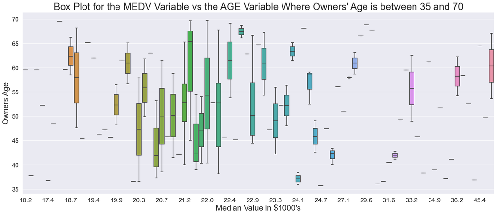

```python
## Create box plot for the MEDV variable vs the AGE variable where the age variable is between 35 and 70

## Query the dataframe's age range for ages between 35 and 70
mid_df=boston_df.query('AGE > 35 & AGE < 70')

## Set the grid layout, grid size, color, and axis font size
sns.set_style("darkgrid", {"grid.color": ".8", "grid.linestyle": ":"})
sns.set(font_scale = 1.5)
plt.rcParams["figure.figsize"] = [18, 8]
plt.rcParams["figure.autolayout"] = True

## Create the boxplot
ax = sns.boxplot(x="MEDV", y="AGE", data=mid_df)

## Iterate ax.get_xticklabels() method. If index is even at intervals of four, then make them visible; else, don't.
for index, label in enumerate(ax.get_xticklabels()):
   if index % 4 == 0:
      label.set_visible(True)
   else:
      label.set_visible(False)

## Create the Graph's Title and Axis labels and set the font sizes
plt.xlabel("Median Value in $1000's", fontsize=20)
plt.ylabel("Owners Age", fontsize=20)
plt.title("Box Plot for the MEDV Variable vs the AGE Variable Where Owners' Age is between 35 and 70", fontsize=25)

## Display the figure
plt.show()
```

### Creating boxplot for the MEDV variable vs the AGE variable for owners whose ages are 70 years or older

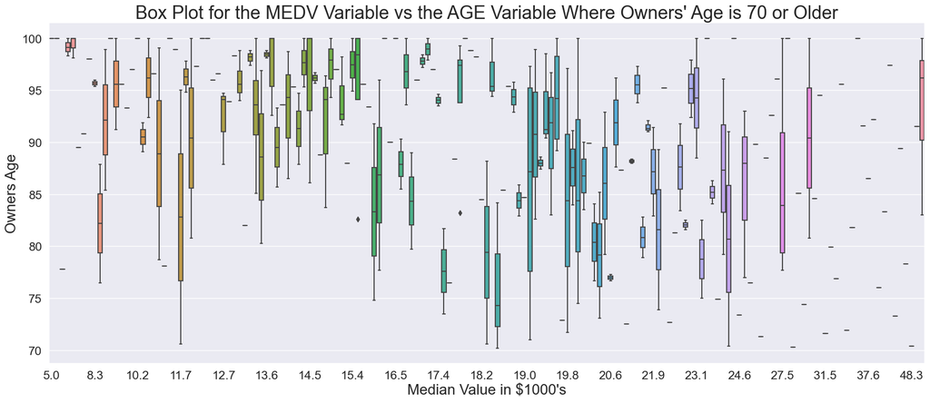

```python
## Create a box plot for the MEDV variable vs the AGE variable where the age variable is greater than or equal to 70

## Query the dataframe's age range for ages between 70 or older
old_df=boston_df.query('AGE >= 70')

## Set the grid layout, grid size, color, and axis font size
sns.set_style("darkgrid", {"grid.color": ".8", "grid.linestyle": ":"})
sns.set(font_scale = 1.5)
plt.rcParams["figure.figsize"] = [18, 8]
plt.rcParams["figure.autolayout"] = True

## Create the boxplot
ax = sns.boxplot(x="MEDV", y="AGE", data=old_df)

## Iterate ax.get_xticklabels() method. If index is even at intervals of eight, then make them visible; else, don't.
for index, label in enumerate(ax.get_xticklabels()):
   if index % 8 == 0:
      label.set_visible(True)
   else:
      label.set_visible(False)

## Create the Graph's Title and Axis labels and set the font sizes
plt.xlabel("Median Value in $1000's", fontsize=20)
plt.ylabel("Owners Age", fontsize=20)
plt.title("Box Plot for the MEDV Variable vs the AGE Variable Where Owners' Age is 70 or Older", fontsize=25)

## Display the figure
plt.show()
```

##### Based on this graph owners whose ages are 70 years or older have the highest concentration of property ownership with the Median Value in $1000's than the two previous groups.

### Creating a scatter plot to show the relationship between Nitric oxide concentrations and the proportion of non-retail business acres per town

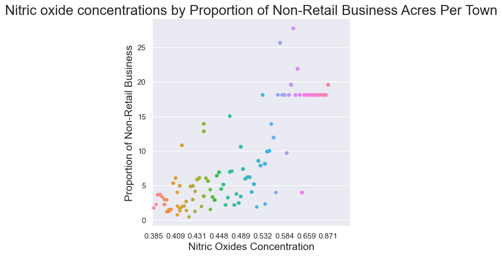

```python
## Scatter plot to show the relationship between Nitric oxide concentrations and the proportion of non-retail business acres per town

## Set the grid layout, grid size, color, and axis font size
sns.set_style("darkgrid", {"grid.color": ".8", "grid.linestyle": ":"})
sns.set(font_scale = 1)
plt.rcParams["figure.figsize"] = [8, 8]
plt.rcParams["figure.autolayout"] = True

## Create the scatter plot
ax = sns.catplot(x='NOX', y= 'INDUS', data=boston_df)

## Create the Graph's Title and Axis labels, set the font sizes and ticks density
plt.xlabel("Nitric Oxides Concentration", fontsize=15)
plt.ylabel("Proportion of Non-Retail Business", fontsize=15)
plt.title("Nitric oxide concentrations by Proportion of Non-Retail Business Acres Per Town", fontsize=20)
plt.xticks([0, 10, 20, 30, 40, 50, 60, 70, 80, 90])

## Display the figure
plt.show()
```

##### The scatter plot demonstrates that the Nitric Oxides Concentration level is higher as the Proportion of Non-Retail Business is also higher.

### Creating a histogram for the Pupil to Teacher Ratio Variable

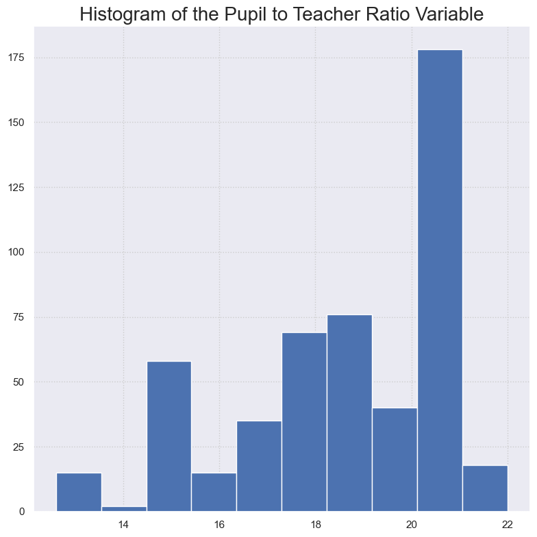

```python
## Creating a histogram for the pupil to teacher ratio variable using the matplotlib library

## Set the grid background color
sns.set_style("darkgrid", {"grid.color": ".8", "grid.linestyle": ":"})

## Create the histogram for
plt.hist(boston_df['PTRATIO'])

## Create the histogram's Title and set the font size
plt.title("Histogram of the Pupil to Teacher Ratio Variable", fontsize=20)
```

##### This histogram is left-skewed. It does not represent the population evenly and is bias towards the higher end of the range.

#### Created by Fritz Tardieu (February 2023)